# Replication Notebook

# “Double Machine Learning based Program Evaluation under Unconfoundedness”

## Michael C. Knaus

### Version 3

This Notebook replicates the main results of the [paper](https://arxiv.org/abs/2003.03191). The notebook should help to show the underlying code for researchers interested in replicating the analysis using the [same data](https://forsbase.unil.ch/project/study-public-overview/17035/1/) or adapting it to new datasets.

The explanations throughout the notebook are kept short. Please see the [paper](https://arxiv.org/abs/2003.03191) for more explanations regarding the parameters of interest and their Double Machine Learning based estimation.

It is indicated in **bold** if a chunk reproduces a Table or graph of the paper.

Click on the “Code” button on the top right of this notebook to “Hide All Code” and see only the results or “Download Rmd” to extract the underlying code.

Running the analyses in this notebook took roughly one week on a [SWITCHengine](https://www.switch.ch/engines/) with eight cores and 32 GB RAM (bottlenecks are the kernel regressions and the depth three policy trees).

Note that the **results might differ for different operating systems**. These results were obtained under Windows Server 2012 R2 Standard and are known to not necessarily replicate under different operating systems.

## Preparation

The analysis is mostly based on the *causalDML* R-package that was developed in parallel to the paper. The preparation of the *“Database_SALMP_MCK2022.Rdata”* that is loaded can be replicated by requesting the [data via FORSbase](https://forsbase.unil.ch/project/study-public-overview/17035/1/) and running the [data preparation file](https://github.com/MCKnaus/mcknaus.github.io/blob/master/assets/code/Data_preparation_MCK2022.R).

```r
## Load relevant packages, in case you did not yet install causalDML uncomment the next two lines
# library(devtools)
# install_github(repo="MCKnaus/causalDML")
library(causalDML)     # version 0.1.0
library(DiagrammeRsvg) # version 0.1
library(estimatr)      # version 0.30.4
library(grf)           # version 2.0.2
library(matrixStats)   # version 0.61.0
library(plyr)          # version 1.8.6
library(policytree)    # version 1.1.1
library(tidyverse)     # version 1.3.1

## Define and set seed
seed = 1234
set.seed(seed)

## Set to path where data are stored for replication
setwd("C:/Users/Administrator/switchdrive/Papers/Multi Treat Labor/Paper/Data")
load("Database_SALMP_MCK2022.Rdata")
```

# Average effects

The *DML_aipw* command estimates first the cross-fitted nuisance parameters and uses them to calculate the double robust scores for APO and ATE, which are then used to estimate the APO and ATE(T).

```r
# Create the ML method to be used for nuisance parameter prediction
forest = create_method("forest_grf",args=list(tune.parameters = "all",seed=seed))

# Run the main function that outputs nuisance parameters, APO and ATE
cDML = DML_aipw(y,w,x,ml_w=list(forest),ml_y=list(forest))
```

## Average potential outcome (APO)

The following table and plot shows the DML estimated APOs.

```r
summary(cDML$APO)
```

```
                APO         SE
no program 14.78249 0.05605243
job search 13.76352 0.11530332
vocational 18.04317 0.42324454
computer   18.21504 0.42531991
language   17.31753 0.37224347
```

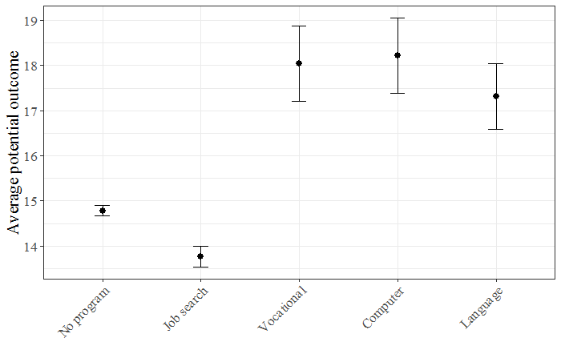

```r
plot(cDML$APO,label_w)
```

## Average treatment effects (ATE and ATET)

### ATE

The following table shows the results of all possible ATEs given the five different treatments:

```r
summary(cDML$ATE)
```

```
                             ATE       SE       t         p
job search - no program -1.01897  0.12568 -8.1079 5.243e-16 ***
vocational - no program  3.26068  0.42627  7.6493 2.049e-14 ***
computer - no program    3.43255  0.42834  8.0137 1.132e-15 ***
language - no program    2.53504  0.37519  6.7566 1.425e-11 ***
vocational - job search  4.27965  0.43819  9.7666 < 2.2e-16 ***
computer - job search    4.45152  0.44018 10.1129 < 2.2e-16 ***
language - job search    3.55401  0.38876  9.1419 < 2.2e-16 ***
computer - vocational    0.17187  0.59980  0.2865    0.7745
language - vocational   -0.72564  0.56313 -1.2886    0.1976
language - computer     -0.89751  0.56463 -1.5896    0.1119
---
Signif. codes:  0 ‘***’ 0.001 ‘**’ 0.01 ‘*’ 0.05 ‘.’ 0.1 ‘ ’ 1
```

### ATET

```r
# Estimate ATETs for the programs
atets = matrix(NA,4,2)
for (i in 1:5) {
  print(label_w[i])
  APO_atet = APO_dml_atet(y,cDML$APO$m_mat,cDML$APO$w_mat,cDML$APO$e_mat,cDML$APO$cf_mat,treated=i)
  ATET = ATE_dml(APO_atet)
  summary(ATET)
  atets[i-1,] = ATET$results[i-1,1:2]
}
```

```
[1] "No program"
                             ATET        SE       t         p
job search - no program -1.037448  0.131322 -7.9000 2.834e-15 ***
vocational - no program  3.312152  0.426211  7.7711 7.896e-15 ***
computer - no program    3.398175  0.430738  7.8892 3.090e-15 ***
language - no program    2.511750  0.380653  6.5985 4.186e-11 ***
vocational - job search  4.349601  0.439621  9.8940 < 2.2e-16 ***
computer - job search    4.435623  0.444012  9.9899 < 2.2e-16 ***
language - job search    3.549198  0.395741  8.9685 < 2.2e-16 ***
computer - vocational    0.086023  0.600992  0.1431    0.8862
language - vocational   -0.800403  0.566550 -1.4128    0.1577
language - computer     -0.886425  0.569881 -1.5555    0.1198
---
Signif. codes:  0 ‘***’ 0.001 ‘**’ 0.01 ‘*’ 0.05 ‘.’ 0.1 ‘ ’ 1
[1] "Job search"
                            ATET       SE       t         p
job search - no program -0.97789  0.12138 -8.0564 7.993e-16 ***
vocational - no program  3.00435  0.47968  6.2632 3.795e-10 ***
computer - no program    3.57931  0.48300  7.4106 1.273e-13 ***
language - no program    2.74899  0.42117  6.5270 6.759e-11 ***
vocational - job search  3.98224  0.48678  8.1808 2.872e-16 ***
computer - job search    4.55720  0.49005  9.2995 < 2.2e-16 ***
language - job search    3.72688  0.42914  8.6846 < 2.2e-16 ***
computer - vocational    0.57497  0.67270  0.8547    0.3927
language - vocational   -0.25536  0.63092 -0.4047    0.6857
language - computer     -0.83032  0.63316 -1.3114    0.1897
---
Signif. codes:  0 ‘***’ 0.001 ‘**’ 0.01 ‘*’ 0.05 ‘.’ 0.1 ‘ ’ 1
[1] "Vocational"
                            ATET       SE       t         p
job search - no program -1.42027  0.15621 -9.0918 < 2.2e-16 ***
vocational - no program  2.79143  0.39170  7.1264 1.041e-12 ***
computer - no program    2.64829  0.46650  5.6769 1.377e-08 ***
language - no program    2.95231  0.40138  7.3554 1.927e-13 ***
vocational - job search  4.21170  0.42335  9.9485 < 2.2e-16 ***
computer - job search    4.06856  0.48615  8.3689 < 2.2e-16 ***
language - job search    4.37257  0.42634 10.2562 < 2.2e-16 ***
computer - vocational   -0.14314  0.58648 -0.2441    0.8072
language - vocational    0.16088  0.54246  0.2966    0.7668
language - computer      0.30402  0.59065  0.5147    0.6068
```

[output cut: 15 more lines]

```
Signif. codes:  0 ‘***’ 0.001 ‘**’ 0.01 ‘*’ 0.05 ‘.’ 0.1 ‘ ’ 1
[1] "Language"
                             ATET        SE       t         p
job search - no program -0.552369  0.193220 -2.8588 0.0042544 **
vocational - no program  3.966546  0.838263  4.7319 2.230e-06 ***
computer - no program    3.952364  0.712957  5.5436 2.975e-08 ***
language - no program    1.083502  0.292444  3.7050 0.0002116 ***
vocational - job search  4.518916  0.849571  5.3191 1.047e-07 ***
computer - job search    4.504733  0.725997  6.2049 5.508e-10 ***
language - job search    1.635872  0.337388  4.8486 1.246e-06 ***
computer - vocational   -0.014182  1.076168 -0.0132 0.9894853
language - vocational   -2.883044  0.881037 -3.2723 0.0010672 **
language - computer     -2.868862  0.761917 -3.7653 0.0001665 ***
---
Signif. codes:  0 ‘***’ 0.001 ‘**’ 0.01 ‘*’ 0.05 ‘.’ 0.1 ‘ ’ 1
```

The numbers above are condensed into **Figure 2** in the paper:

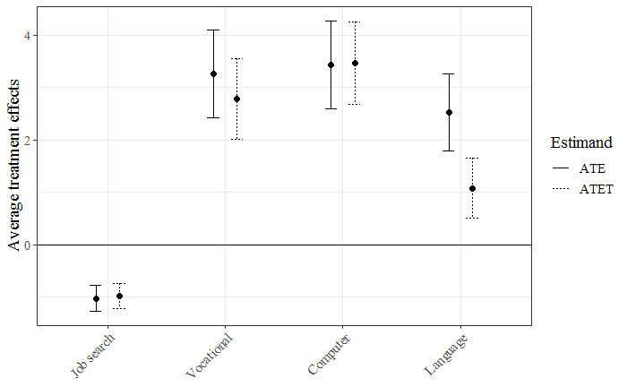

```r
# Plot ATE and ATET together
ates = cDML$ATE$results[1:4,1:2]
df = data.frame(Estimand = c(rep("ATE",4),rep("ATET",4)),
                program = factor(rep(label_w[-1],2),label_w[-1]),
                effect = c(ates[,1],atets[,1]))
df$low = df$effect - 1.96 * c(ates[,2],atets[,2])
df$up = df$effect + 1.96 * c(ates[,2],atets[,2])

ggplot(data = df,mapping = aes(x = program, y = effect,ymin = low,
                                   ymax = up,group = Estimand, linetype = Estimand)) +
          geom_point(size=2,position = position_dodge(width = 0.4)) +
          geom_errorbar(width=0.2,position = position_dodge(width = 0.4))  +
          theme_bw() + theme(axis.text.x = element_text(angle = 45, hjust = 1),axis.title.x=element_blank()) +
          ylab("Average treatment effects") + geom_hline(yintercept = 0) +
          theme(text=element_text(family="serif",size = 14, colour="black"))
```

# Heterogeneous effects

The output of the *DML_aipw* command contains an *APO_dml* object and an *ATE_dml* object that carry a *gamma* and *delta* matrix storing the doubly robust APO and ATE scores, respectively. The *delta* matrix of the *ATE_dml* object can be used to conveniently estimate heterogeneous effects.

## GATEs

Group average treatment effects (GATEs) represent the average effects in different subgroups. Such subgroup analyses are an integral part of most program evaluations and usually require to rerun the preferred method in subsamples. Using the doubly robust ATE score as pseudo outcome in a standard OLS regression and a group indicator as explanatory variable estimates GATEs.

The results shown in the following are very similar to those presented in **Table 4** of the paper:

### Gender

**Table 4 Panel A:**

```r
# GATEs female
for (i in 1:4) {
  cat(paste("\n\n",label_w[i+1]),"\n")
  temp_ols = lm_robust(cDML$ATE$delta[,i] ~ z_blp$female)
  print(summary(temp_ols))
}
```

```
 Job search

Call:
lm_robust(formula = cDML$ATE$delta[, i] ~ z_blp$female)

Standard error type:  HC2

Coefficients:
             Estimate Std. Error t value  Pr(>|t|) CI Lower CI Upper    DF
(Intercept)   -1.2852      0.166  -7.743 9.863e-15  -1.6106  -0.9599 62495
z_blp$female   0.6038      0.254   2.378 1.742e-02   0.1061   1.1016 62495

Multiple R-squared:  9.106e-05 ,    Adjusted R-squared:  7.506e-05
F-statistic: 5.654 on 1 and 62495 DF,  p-value: 0.01742


 Vocational

Call:
lm_robust(formula = cDML$ATE$delta[, i] ~ z_blp$female)

Standard error type:  HC2

Coefficients:
             Estimate Std. Error t value  Pr(>|t|) CI Lower CI Upper    DF
(Intercept)     3.824     0.5512   6.937 4.043e-12    2.743   4.9039 62495
z_blp$female   -1.277     0.8660  -1.474 1.404e-01   -2.974   0.4208 62495

Multiple R-squared:  3.538e-05 ,    Adjusted R-squared:  1.938e-05
F-statistic: 2.173 on 1 and 62495 DF,  p-value: 0.1404


 Computer

Call:
lm_robust(formula = cDML$ATE$delta[, i] ~ z_blp$female)

Standard error type:  HC2

Coefficients:
             Estimate Std. Error t value  Pr(>|t|) CI Lower CI Upper    DF
(Intercept)     2.334     0.6004   3.888 0.0001012   1.1575    3.511 62495
z_blp$female    2.491     0.8512   2.926 0.0034308   0.8226    4.159 62495

Multiple R-squared:  0.0001334 ,    Adjusted R-squared:  0.0001174
F-statistic: 8.564 on 1 and 62495 DF,  p-value: 0.003431


 Language

Call:
lm_robust(formula = cDML$ATE$delta[, i] ~ z_blp$female)

Standard error type:  HC2

Coefficients:
             Estimate Std. Error t value  Pr(>|t|) CI Lower CI Upper    DF
(Intercept)     3.402     0.4564   7.455 9.098e-14    2.508    4.297 62495
z_blp$female   -1.967     0.7729  -2.545 1.094e-02   -3.482   -0.452 62495

Multiple R-squared:  0.0001084 ,    Adjusted R-squared:  9.241e-05
F-statistic: 6.476 on 1 and 62495 DF,  p-value: 0.01094
```

### Foreigner

**Table 4 Panel B:**

```r
# GATEs foreigner
for (i in 1:4) {
   cat(paste("\n\n",label_w[i+1]),":\n")
  temp_ols = lm_robust(cDML$ATE$delta[,i] ~ z_blp$foreigner)
  print(summary(temp_ols))
}
```

```
 Job search :

Call:
lm_robust(formula = cDML$ATE$delta[, i] ~ z_blp$foreigner)

Standard error type:  HC2

Coefficients:
                Estimate Std. Error t value  Pr(>|t|) CI Lower CI Upper    DF
(Intercept)      -1.2720     0.1598  -7.960 1.751e-15  -1.5852  -0.9588 62495
z_blp$foreigner   0.6989     0.2583   2.705 6.823e-03   0.1926   1.2052 62495

Multiple R-squared:  0.0001143 ,    Adjusted R-squared:  9.83e-05
F-statistic:  7.32 on 1 and 62495 DF,  p-value: 0.006823


 Vocational :

Call:
lm_robust(formula = cDML$ATE$delta[, i] ~ z_blp$foreigner)

Standard error type:  HC2

Coefficients:
                Estimate Std. Error t value  Pr(>|t|) CI Lower CI Upper    DF
(Intercept)        2.476     0.5257   4.709 2.491e-06   1.4454    3.506 62495
z_blp$foreigner    2.168     0.8969   2.417 1.565e-02   0.4098    3.926 62495

Multiple R-squared:  9.557e-05 ,    Adjusted R-squared:  7.957e-05
F-statistic: 5.842 on 1 and 62495 DF,  p-value: 0.01565


 Computer :

Call:
lm_robust(formula = cDML$ATE$delta[, i] ~ z_blp$foreigner)

Standard error type:  HC2

Coefficients:
                Estimate Std. Error t value  Pr(>|t|) CI Lower CI Upper    DF
(Intercept)       3.7508     0.5042  7.4392 1.026e-13    2.763   4.7390 62495
z_blp$foreigner  -0.8789     0.9299 -0.9452 3.446e-01   -2.701   0.9436 62495

Multiple R-squared:  1.556e-05 ,    Adjusted R-squared:  -4.403e-07
F-statistic: 0.8934 on 1 and 62495 DF,  p-value: 0.3446


 Language :

Call:
lm_robust(formula = cDML$ATE$delta[, i] ~ z_blp$foreigner)

Standard error type:  HC2

Coefficients:
                Estimate Std. Error t value  Pr(>|t|) CI Lower CI Upper    DF
(Intercept)        3.564     0.5157   6.910 4.881e-12    2.553    4.574 62495
z_blp$foreigner   -2.841     0.7169  -3.963 7.424e-05   -4.246   -1.436 62495

Multiple R-squared:  0.0002119 ,    Adjusted R-squared:  0.0001959
F-statistic:  15.7 on 1 and 62495 DF,  p-value: 7.424e-05
```

### Employability

**Table 4 Panel C:**

```r
# GATEs employability
for (i in 1:4) {
   cat(paste("\n\n",label_w[i+1]),":\n")
  temp_ols = lm_robust(cDML$ATE$delta[,i] ~ z_blp$employability)
  print(summary(temp_ols))
}
```

```
 Job search :

Call:
lm_robust(formula = cDML$ATE$delta[, i] ~ z_blp$employability)

Standard error type:  HC2

Coefficients:
                     Estimate Std. Error t value Pr(>|t|) CI Lower CI Upper    DF
(Intercept)           -0.1791     0.3303 -0.5422 0.587686  -0.8264   0.4683 62494
z_blp$employability2  -0.9344     0.3609 -2.5889 0.009631  -1.6419  -0.2270 62494
z_blp$employability3  -1.5043     0.4960 -3.0327 0.002425  -2.4765  -0.5321 62494

Multiple R-squared:  0.0001624 ,    Adjusted R-squared:  0.0001304
F-statistic: 5.035 on 2 and 62494 DF,  p-value: 0.006506


 Vocational :

Call:
lm_robust(formula = cDML$ATE$delta[, i] ~ z_blp$employability)

Standard error type:  HC2

Coefficients:
                     Estimate Std. Error t value  Pr(>|t|) CI Lower CI Upper    DF
(Intercept)             5.479      1.040   5.268 1.380e-07    3.441   7.5176 62494
z_blp$employability2   -2.412      1.157  -2.084 3.714e-02   -4.680  -0.1437 62494
z_blp$employability3   -4.420      1.517  -2.914 3.575e-03   -7.394  -1.4467 62494

Multiple R-squared:  0.0001116 ,    Adjusted R-squared:  7.957e-05
F-statistic: 4.312 on 2 and 62494 DF,  p-value: 0.01341


 Computer :

Call:
lm_robust(formula = cDML$ATE$delta[, i] ~ z_blp$employability)

Standard error type:  HC2
```

[output cut: 11 more lines]

```
 Language :

Call:
lm_robust(formula = cDML$ATE$delta[, i] ~ z_blp$employability)

Standard error type:  HC2

Coefficients:
                     Estimate Std. Error t value Pr(>|t|) CI Lower CI Upper    DF
(Intercept)            2.6120     0.8533  3.0612 0.002205   0.9396    4.284 62494
z_blp$employability2  -0.1781     0.9612 -0.1853 0.853023  -2.0621    1.706 62494
z_blp$employability3   0.5936     1.4845  0.3999 0.689250  -2.3160    3.503 62494

Multiple R-squared:  5.801e-06 ,    Adjusted R-squared:  -2.62e-05
F-statistic: 0.1824 on 2 and 62494 DF,  p-value: 0.8333
```

## Best linear prediction of GATE

We can also model effect heterogeneity in a multivariate OLS. Again the ATE score is reused as a pseudo-outcome in a plain vanilla OLS regression with heteroscedasticity robust standard errors. This replicates the results of **Table 5**:

```r
## BLP CATEs
for (i in 1:4) {
  cat(paste("\n\n",label_w[i+1]),":\n")
  temp_df = data.frame(y = cDML$ATE$delta[,i])
  temp_df = cbind(temp_df,z_blp)
  temp_ols = lm_robust(as.formula("y ~ ."),data = temp_df)
  print(summary(temp_ols))
}
```

```
 Job search :

Call:
lm_robust(formula = as.formula("y ~ ."), data = temp_df)

Standard error type:  HC2

Coefficients:
                   Estimate Std. Error t value  Pr(>|t|)  CI Lower CI Upper    DF
(Intercept)        -0.47643    0.70417 -0.6766 4.987e-01 -1.856597  0.90375 62490
female              0.25428    0.26765  0.9501 3.421e-01 -0.270306  0.77887 62490
age                 0.02325    0.01491  1.5595 1.189e-01 -0.005972  0.05248 62490
foreigner           0.49739    0.26543  1.8739 6.095e-02 -0.022865  1.01764 62490
employability2     -0.65188    0.37035 -1.7602 7.838e-02 -1.377768  0.07400 62490
employability3     -1.03371    0.51072 -2.0240 4.297e-02 -2.034709 -0.03270 62490
past_incomein10000 -0.25548    0.06438 -3.9683 7.247e-05 -0.381670 -0.12930 62490

Multiple R-squared:  0.0006031 ,    Adjusted R-squared:  0.0005072
F-statistic: 6.953 on 6 and 62490 DF,  p-value: 2.102e-07


 Vocational :

Call:
lm_robust(formula = as.formula("y ~ ."), data = temp_df)

Standard error type:  HC2

Coefficients:
                   Estimate Std. Error t value Pr(>|t|)  CI Lower CI Upper    DF
(Intercept)         4.46034    2.39936   1.859 0.063036 -0.242417  9.16310 62490
female             -2.11727    0.92022  -2.301 0.021404 -3.920898 -0.31364 62490
age                 0.09153    0.04926   1.858 0.063145 -0.005014  0.18808 62490
foreigner           1.60120    0.90536   1.769 0.076968 -0.173300  3.37570 62490
employability2     -1.63636    1.17868  -1.388 0.165050 -3.946577  0.67385 62490
employability3     -3.12839    1.54849  -2.020 0.043358 -6.163437 -0.09334 62490
past_incomein10000 -0.62267    0.22785  -2.733 0.006281 -1.069249 -0.17609 62490

Multiple R-squared:  0.0003749 ,    Adjusted R-squared:  0.0002789
F-statistic: 4.122 on 6 and 62490 DF,  p-value: 0.0003831
```

[output cut: 27 more lines]

```

Standard error type:  HC2

Coefficients:
                   Estimate Std. Error t value  Pr(>|t|) CI Lower CI Upper    DF
(Intercept)         6.06589    2.09297  2.8982 0.0037542   1.9637 10.16812 62490
female             -1.60872    0.80036 -2.0100 0.0444346  -3.1774 -0.04002 62490
age                -0.06923    0.04522 -1.5311 0.1257595  -0.1579  0.01940 62490
foreigner          -2.77057    0.73286 -3.7805 0.0001567  -4.2070 -1.33417 62490
employability2     -0.77969    0.98917 -0.7882 0.4305667  -2.7185  1.15909 62490
employability3     -0.46895    1.52730 -0.3070 0.7588092  -3.4625  2.52457 62490
past_incomein10000  0.31291    0.17909  1.7473 0.0805960  -0.0381  0.66392 62490

Multiple R-squared:  0.0004017 ,    Adjusted R-squared:  0.0003058
F-statistic: 5.219 on 6 and 62490 DF,  p-value: 2.215e-05
```

```r
rm(temp_df,temp_ols)
```

## Kernel regression GATEs

Next, we reuse the ATE score as pseudo outcome in a one-dimensional kernel regression. The *causalDML* package implements this based on the *[np](https://cran.r-project.org/web/packages/np/index.html)* package.

```r
## Kernel regression CATEs
list_kr_cates_inc = vector("list",4)
for (i in 1:4) {
  list_kr_cates_inc[[i]] = kr_cate(cDML$ATE$delta[,i],x[,"past_income"])
}
```

The figures show the results in the following order: job search (**Figure 3 (a)**), vocational (**Figure 3 (c)**), computer (**Figure 3 (e)**) and language (**Figure 3 (g)**):

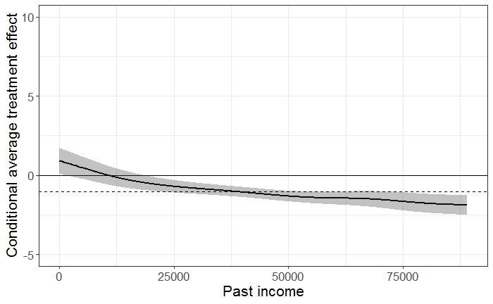

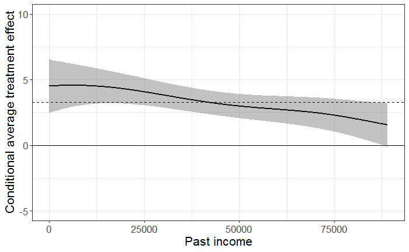

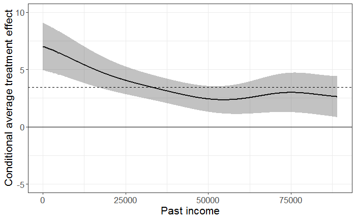

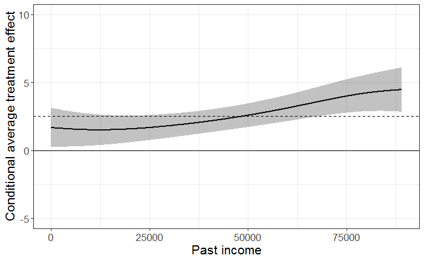

```r
# Plot Kernel regression CATEs
for (i in 1:4) {
  print(plot(list_kr_cates_inc[[i]],z_label="Past income",yrange=c(-5,10)))
}
```

## Series regression GATEs

Next, we reuse the ATE score as pseudo outcome in a one-dimensional series regression. The *causalDML* package implements this based on the *[crs](https://cran.r-project.org/web/packages/crs/index.html)* package.

```r
## Series regression GATEs
list_sr_cates_inc = vector("list",4)
for (i in 1:4) {
  list_sr_cates_inc[[i]] = spline_cate(cDML$ATE$delta[,i],x[,"past_income"])
}
```

The figures show the results in the following order: job search (**Figure 3 (b)**), vocational (**Figure 3 (d)**), computer (**Figure 3 (f)**) and language (**Figure 3 (h)**):

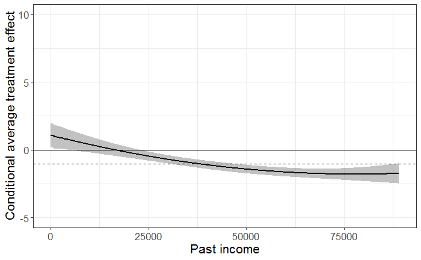

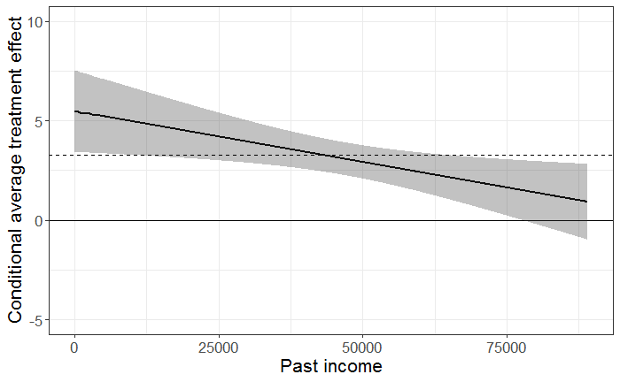

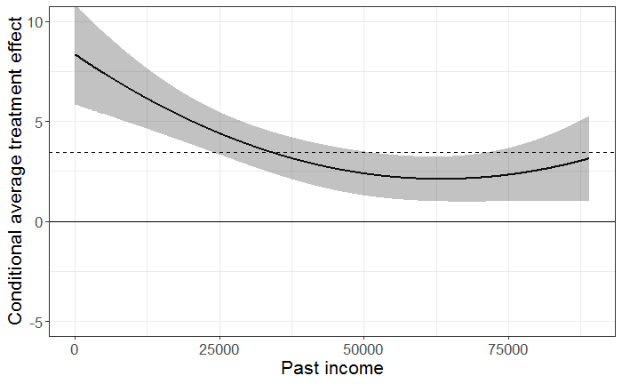

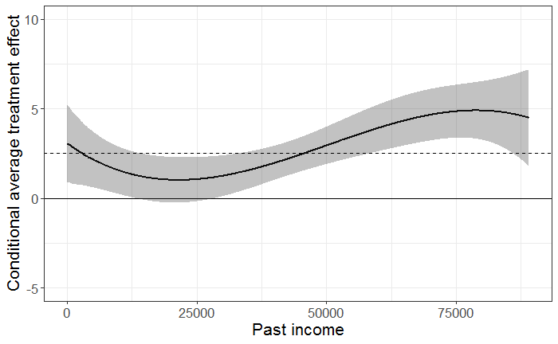

```r
# Plot Series regression GATEs
for (i in 1:4) {
  print(plot(list_sr_cates_inc[[i]],z_label="Past income",yrange=c(-5,10)))
}
```

## Individualized average treatment effects

We further predict the individualized average treatment effects (IATEs) using the DR- and the NDR-learner. Like in the paper, we focus on the out-of-sample variant described in Algorithms 1 and 2 of the paper that are implemented using the *ndr_learner* function of the *causalDML* package.

```r
## (N)DR-learner
ndr = ndr_learner(y,w,x,ml_w = list(forest),ml_y = list(forest),ml_tau = list(forest),compare_all = FALSE)
```

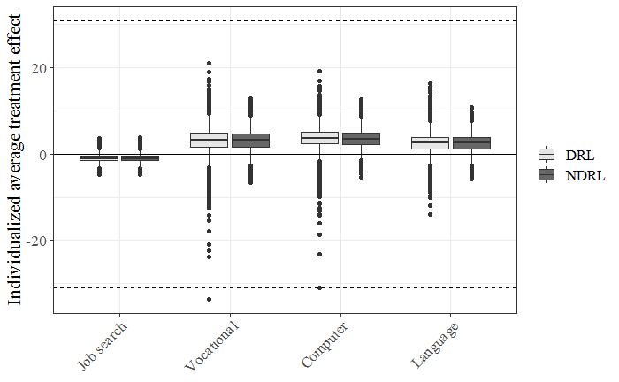

```r
# Plot the results
df_box = NULL
for (i in 1:4) {
  df = data.frame("DRL" = ndr$cates[i,,1], "NDRL" = ndr$cates[i,,2])
  df = gather(df)
  df = cbind(label_w[i+1],df)
  colnames(df)[1] = "label"
  df_box = rbind(df_box,df)
}
ggplot(data=df_box) + geom_boxplot( aes(x=factor(label,label_w[-1]),y=value,fill=key)) +
  theme_bw() + theme(axis.title.x=element_blank(),legend.title = element_blank()) +
  ylab("Individualized average treatment effect") + geom_hline(yintercept = 0) + geom_hline(yintercept = -31,linetype="dashed") +
  geom_hline(yintercept = 31,linetype="dashed") +
  theme(text=element_text(family="serif",size = 16, colour="black"),axis.text.x = element_text(angle = 45, hjust = 1)) +
  scale_fill_grey(start = 0.9,end=0.4)
```

This replicates **Table 6**:

```r
# Classification analysis
diff = matrix(NA,ncol(x),4)
rownames(diff) = label_x
colnames(diff) = label_w[-1]
for (i in 1:4) {
  diff[,i] = clan(ndr$cates[i,,2],scale(x))[,5][-1] - clan(ndr$cates[i,,2],scale(x))[,1][-1]
}
round(diff[order(rowMaxs(abs(diff)),decreasing=T),][1:7,],digits=2)
```

```
                                                 Job search Vocational Computer Language
Past income                                           -1.32      -0.84    -1.17     1.01
Previous job: unskilled worker                         1.02       0.68     0.34    -1.24
Mother tongue other than German, French, Italian       0.69       0.68     0.00    -1.17
Qualification: some degree                            -0.88      -0.65    -0.41     1.15
Swiss citizen                                         -0.66      -0.60     0.12     1.11
Fraction of months employed last 2 years              -1.06      -0.37    -0.47     0.30
Qualification: unskilled                               0.81       0.41     0.32    -1.02
```

## Optimal assigment rules

Finally, the *gamma* matrix of the *APO_dml* object can be used as input for the *[policytree](https://cran.r-project.org/web/packages/policytree/index.html)* R package.

```r
## Estimate optimal assignment rule estimation
# Depth one
pt_low1 = policy_tree(x_pt_low,cDML$APO$gamma,depth = 1)
pt_high1 = policy_tree(x_pt_high,cDML$APO$gamma,depth = 1)

# Depth two
pt_low2 = policy_tree(x_pt_low,cDML$APO$gamma,depth = 2)
pt_high2 = policy_tree(x_pt_high,cDML$APO$gamma,depth = 2)
```

For the depth three tree, we round past income to CHF 1000 to speed up computation:

```r
# Depth three
# Round past income variable to 1000 such that it runs in finite time
x_pt_low_round = x_pt_low
x_pt_low_round[,5] = round_any(x_pt_low[,5],1000)
pt_low3 = policy_tree(x_pt_low_round,cDML$APO$gamma,depth = 3)
x_pt_high_round = x_pt_high
x_pt_high_round[,3] = round_any(x_pt_high[,3],1000)
pt_high3 = policy_tree(x_pt_high_round,cDML$APO$gamma,depth = 3)
```

This replicates the four subgraphs of **Figure 5**:

```r
## Plot optimal assignment rule estimation
plot(pt_low1,label_w)
```

[interactive chart not shown]

```r
plot(pt_high1,label_w)
```

[interactive chart not shown]

```r
plot(pt_low2,label_w)
```

[interactive chart not shown]

```r
plot(pt_high2,label_w)
```

[interactive chart not shown]

This replicates **Panel A of Table 7**:

```r
# Panel A
table(predict(pt_low1,newdata=x_pt_low)) / length(y) * 100
```

```
       3        4
55.90668 44.09332
```

```r
table(predict(pt_low2,newdata=x_pt_low)) / length(y) * 100
```

```
       3        4        5
31.88793 42.99726 25.11481
```

```r
table(predict(pt_low3,newdata=x_pt_low)) / length(y) * 100
```

```
       3        4        5
46.61184 36.59696 16.79121
```

```r
table(predict(pt_high1,newdata=x_pt_high)) / length(y) * 100
```

```
       4        5
53.50817 46.49183
```

```r
table(predict(pt_high2,newdata=x_pt_high)) / length(y) * 100
```

```
       3        4        5
23.00270 36.58896 40.40834
```

```r
table(predict(pt_high3,newdata=x_pt_high)) / length(y) * 100
```

```
       3        4        5
42.20363 30.35346 27.44292
```

Finally, we apply a short program to cross-validate the policy trees.

```r
## Cross-validate trees
# Short program implementing the cross-validation of trees
cv_policy_tree = function(APO_dml,x,...) {
  nfolds = ncol(APO_dml$cf_mat)
  folds = APO_dml$cf_mat

  list_trees = vector("list",nfolds)
  cv_policy = matrix(NA,nrow(APO_dml$cf_mat),nfolds)
  cv_gamma = rep(0,nrow(APO_dml$cf_mat))

  for (i in 1:nfolds) {
    list_trees[[i]] = policy_tree(x[folds[,i]==0,],APO_dml$gamma[folds[,i]==0,],...)
    cv_policy[,i] = predict(list_trees[[i]],x)
    for (j in 1:ncol(APO_dml$gamma)) {
      cv_gamma[folds[,i]==1] = cv_gamma[folds[,i]==1] + (cv_policy[folds[,i]==1,i] == j) * APO_dml$gamma[folds[,i]==1,j]
    }
  }
  list("trees"=list_trees,"policy_mat"=cv_policy,"gamma"=cv_gamma)
}

cv_pt_low1 = cv_policy_tree(cDML$APO,x_pt_low,depth = 1)
cv_pt_high1 = cv_policy_tree(cDML$APO,x_pt_high,depth = 1)
cv_pt_low2 = cv_policy_tree(cDML$APO,x_pt_low,depth = 2)
cv_pt_high2 = cv_policy_tree(cDML$APO,x_pt_high,depth = 2)
cv_pt_low3 = cv_policy_tree(cDML$APO,x_pt_low_round,depth = 3)
cv_pt_high3 = cv_policy_tree(cDML$APO,x_pt_high_round,depth = 3)
```

This replicates the results shown in **Panel B of Table 7**:

```r
# Panel B
cat("\n Depth 1 & 5 variables \n")
```

```
 Depth 1 & 5 variables
```

```r
cv_resultsl1 = summary(lm(cv_pt_low1$gamma - cDML$APO$gamma ~ 1))
for (i in 1:5) print(cv_resultsl1[[i]]$coefficients)
```

```
            Estimate Std. Error  t value     Pr(>|t|)
(Intercept) 3.748397  0.4048685 9.258308 2.140316e-20
            Estimate Std. Error  t value     Pr(>|t|)
(Intercept) 4.767369  0.4174018 11.42153 3.497432e-30
             Estimate Std. Error  t value  Pr(>|t|)
(Intercept) 0.4877196  0.4369752 1.116127 0.2643722
            Estimate Std. Error   t value  Pr(>|t|)
(Intercept) 0.315847  0.4753149 0.6645005 0.5063725
            Estimate Std. Error  t value   Pr(>|t|)
(Intercept)  1.21336  0.4920543 2.465906 0.01366937
```

```r
cat("\n Depth 2 & 5 variables \n")
```

```
 Depth 2 & 5 variables
```

```r
cv_resultsl2 = summary(lm(cv_pt_low2$gamma - cDML$APO$gamma ~ 1))
for (i in 1:5) print(cv_resultsl2[[i]]$coefficients)
```

```
            Estimate Std. Error  t value     Pr(>|t|)
(Intercept) 3.988737  0.4075943 9.786047 1.341782e-22
            Estimate Std. Error  t value     Pr(>|t|)
(Intercept) 5.007709  0.4200489 11.92173 9.897219e-33
            Estimate Std. Error  t value  Pr(>|t|)
(Intercept) 0.728059  0.4764307 1.528153 0.1264796
             Estimate Std. Error  t value  Pr(>|t|)
(Intercept) 0.5561864  0.4639521 1.198801 0.2306098
            Estimate Std. Error  t value    Pr(>|t|)
(Intercept) 1.453699  0.4680231 3.106042 0.001896946
```

```r
cat("\n Depth 3 & 5 variables \n")
```

```
 Depth 3 & 5 variables
```

```r
cv_resultsl3 = summary(lm(cv_pt_low3$gamma - cDML$APO$gamma ~ 1))
for (i in 1:5) print(cv_resultsl3[[i]]$coefficients)
```

```
            Estimate Std. Error  t value     Pr(>|t|)
(Intercept) 3.499932  0.4139583 8.454792 2.855177e-17
            Estimate Std. Error t value     Pr(>|t|)
(Intercept) 4.518903  0.4262032 10.6027 3.047711e-26
             Estimate Std. Error   t value  Pr(>|t|)
(Intercept) 0.2392538  0.4526634 0.5285467 0.5971218
             Estimate Std. Error   t value  Pr(>|t|)
(Intercept) 0.0673811  0.4899702 0.1375208 0.8906196
             Estimate Std. Error  t value   Pr(>|t|)
(Intercept) 0.9648941  0.4706919 2.049948 0.04037364
```

```r
cat("\n Depth 1 & 16 variables \n")
```

```
 Depth 1 & 16 variables
```

```r
cv_resultsh1 = summary(lm(cv_pt_high1$gamma - cDML$APO$gamma ~ 1))
for (i in 1:5) print(cv_resultsh1[[i]]$coefficients)
```

```
            Estimate Std. Error  t value     Pr(>|t|)
(Intercept) 3.720499  0.4104394 9.064673 1.284803e-19
            Estimate Std. Error  t value     Pr(>|t|)
(Intercept) 4.739471   0.422858 11.20819 3.963171e-29
             Estimate Std. Error   t value  Pr(>|t|)
(Intercept) 0.4598215  0.5189743 0.8860198 0.3756103
             Estimate Std. Error   t value  Pr(>|t|)
(Intercept) 0.2879488  0.4803275 0.5994844 0.5488521
            Estimate Std. Error  t value    Pr(>|t|)
(Intercept) 1.185462  0.4043294 2.931921 0.003369945
```

```r
cat("\n Depth 2 & 16 variables \n")
```

```
 Depth 2 & 16 variables
```

```r
cv_resultsh2 = summary(lm(cv_pt_high2$gamma - cDML$APO$gamma ~ 1))
for (i in 1:5) print(cv_resultsh2[[i]]$coefficients)
```

```
            Estimate Std. Error  t value     Pr(>|t|)
(Intercept) 3.632815   0.426687 8.514005 1.716914e-17
            Estimate Std. Error  t value     Pr(>|t|)
(Intercept) 4.651787  0.4386062 10.60584 2.947185e-26
             Estimate Std. Error   t value  Pr(>|t|)
(Intercept) 0.3721376  0.4706731 0.7906499 0.4291513
             Estimate Std. Error   t value  Pr(>|t|)
(Intercept) 0.2002649  0.5256943 0.3809532 0.7032393
            Estimate Std. Error  t value    Pr(>|t|)
(Intercept) 1.097778  0.4234822 2.592265 0.009536858
```

```r
cat("\n Depth 3 & 16 variables \n")
```

```
 Depth 3 & 16 variables
```

```r
cv_resultsh3 = summary(lm(cv_pt_high3$gamma - cDML$APO$gamma ~ 1))
for (i in 1:5) print(cv_resultsh3[[i]]$coefficients)
```

```
            Estimate Std. Error  t value     Pr(>|t|)
(Intercept) 3.942688  0.4226603 9.328266 1.110005e-20
            Estimate Std. Error  t value     Pr(>|t|)
(Intercept) 4.961659  0.4347275 11.41326 3.845809e-30
             Estimate Std. Error  t value  Pr(>|t|)
(Intercept) 0.6820098  0.4674601 1.458969 0.1445787
             Estimate Std. Error  t value  Pr(>|t|)
(Intercept) 0.5101371  0.4932374 1.034263 0.3010173
            Estimate Std. Error  t value    Pr(>|t|)
(Intercept)  1.40765  0.4603621 3.057702 0.002231354
```